# Pruebas de hipótesis en R

7. Utilice la prueba M de Box de Biotools y verifique si ambas matrices de varianzas y covarianzas son estadísticamente iguales al 95%. (cuide el cálculo de las varianzas en datos angulares). De ser diferentes las varianzas consulte el texto de Wichern para que utilice la prueba de Hotelling para varianzas y covarianzas desiguales y con la ayuda de alguna función en R/Python contraste las hipótesis bivariadas de longitud y ángulo nuevamente.

```r
## Matriz de varianzas y covarianzas metodo A
data.a <- as.matrix((filter(datos5[, 1:2], disp == "A")), ncol = 2)
sa <- var(data.a)
sa
```

```
##                 distancia          angulo
## distancia 43540.489698214 -2.79522189e-01
## angulo       -0.279522189  5.45855368e-05
```

```r
## Matriz de varianzas y covarianzas metodo B
data.b <- as.matrix((filter(datos5[, 1:2], disp == "B")), ncol = 2)
sb <- var(data.b)
sb
```

```
##              distancia         angulo
## distancia 43794.854429 -100.166801766
## angulo     -100.166802    0.500745567
```

```r
## Prueba M de Box
boxM(datos5[,1:2], datos5[,3])
```

```
##
##  Box's M-test for Homogeneity of Covariance Matrices
##
## data:  datos5[, 1:2]
## Chi-Sq (approx.) = 46.49637, df = 3, p-value = 4.44783e-10
```

De acuerdo a la prueba M de Box no se puede asumir que las matrices de varianzas y covarianzas son iguales, por lo anterior se buscaron otras funciones de R que de las librerias *ergm* y *rrcov* que permiten realizar la prueba T$^2$ de Hotelling indicando este aspecto.

```r
approx.hotelling.diff.test(data.a[,-3], data.b[,-3], mu0 = 0, assume.indep = T, var.equal = F)
```

```
##
##  Hotelling's Two -Sample T^2-Test
##
## data:
## T^2 = 2.704977, param = 2.00000, df = 12.65632, p-value = 0.323394
## alternative hypothesis: two.sided
## null values:
## distancia    angulo
##         0         0
## sample estimates:
##   distancia      angulo
## 0.173750000 0.360729167
```

```r
T2.test(data.a[,-3], data.b[,-3], method = "c")
```

```
##
##  Two-sample Hotelling test
##
## data:  data.a[, -3] and data.b[, -3]
## T2 = 2.704977, F = 1.255882, df1 = 2, df2 = 13, p-value = 0.317201
## alternative hypothesis: true difference in mean vectors is not equal to (0,0)
## sample estimates:
##               distancia     angulo
## mean x-vector 410.02875 90.0022222
## mean y-vector 409.85500 89.6414931
```

Obsérvese que cuando se indica que la matriz de covarianza no es igual, aumenta el p-valor, no obstante se mantiene la misma conclusión sobre la existencia de igualdad del vector de medias entre los dos grupos de datos.

8. Realice algún gráfico radial o de datos circulares para visualizar el comportamiento de los ángulos y simultáneamente visualice las distancias.

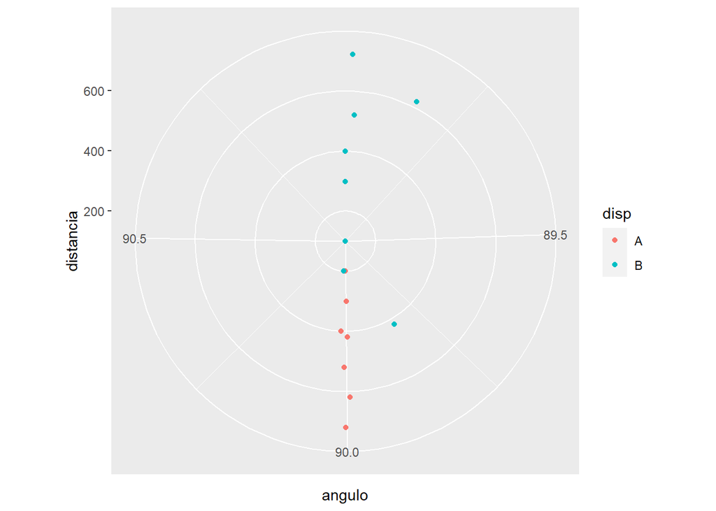

```r
ggplot(data=datos5, aes(x=angulo, y=distancia, col=disp, group=disp)) + geom_point() + coord_polar()
```

1. Si ambos dispositivos se comportan igual para ambas medidas (es decir no se rechazó $H_o$ bivariada, utilice el análisis de regresión lineal para ajustar un modelo para estimar la distancia a partir del ángulo. ¿Vale la pena este ajuste? Ajuste el mismo modelo con el inverso de la distancia y compare resultados. ¿Como a mayor distancia la medida de longitud se puede tornar más imprecisa, valdría ponderar el ángulo por el inverso de la distancia para obtener el ángulo promedio de todas las medidas? Realice el cálculo ponderado y compare con la media aritmética usual del ángulo. Explique estos resultados.

Debido a que no se pudo rechazar la $H_o$ de igualdad de medias, se realiza un modelo lineal entre la distancia y el ángulo:

```r
model1=lm(datos5$distancia ~ datos5$angulo)
summary(model1)
```

```
##
## Call:
## lm(formula = datos5$distancia ~ datos5$angulo)
##
## Residuals:
##       Min        1Q    Median        3Q       Max
## -278.0460 -157.5174   18.3621  107.8981  341.5290
##
## Coefficients:
##                 Estimate Std. Error  t value Pr(>|t|)
## (Intercept)   16090.9629  8363.2881  1.92400 0.074927 .
## datos5$angulo  -174.5791    93.1083 -1.87501 0.081805 .
## ---
## Signif. codes:  0 '***' 0.001 '**' 0.01 '*' 0.05 '.' 0.1 ' ' 1
##
## Residual standard error: 186.823 on 14 degrees of freedom
## Multiple R-squared:  0.200716,   Adjusted R-squared:  0.143624
## F-statistic: 3.51567 on 1 and 14 DF,  p-value: 0.0818049
```

Por lo anterior, se optó realizar el segundo modelo propuesto (inverso de la distancia)

```r
model2=lm(1/datos5$distancia ~ datos5$angulo)
summary(model2)
```

```
##
## Call:
## lm(formula = 1/datos5$distancia ~ datos5$angulo)
##
## Residuals:
##          Min           1Q       Median           3Q          Max
## -0.002420437 -0.001537940 -0.000851183  0.000508107  0.006184345
##
## Coefficients:
##                  Estimate  Std. Error  t value Pr(>|t|)
## (Intercept)   -0.14146822  0.12201305 -1.15945  0.26567
## datos5$angulo  0.00161416  0.00135837  1.18831  0.25448
##
## Residual standard error: 0.00272559 on 14 degrees of freedom
## Multiple R-squared:  0.0916218,  Adjusted R-squared:  0.0267376
## F-statistic: 1.41208 on 1 and 14 DF,  p-value: 0.254479
```

Se calculan los valores ponderados por el inverso de la distancia:

```r
datos5a$inversdis=1/datos5a$distancia
datos5a$angulopond=datos5a$inversdis*datos5a$angulo
datos5b$inversdis=1/datos5b$distancia
datos5b$angulopond=datos5b$inversdis*datos5b$angulo
cor(datos5b$angulopond,datos5a$angulopond)
```

```
## [1] 0.999956602
```

```r
mean(datos5a$angulopond)
```

```
## [1] 0.316513643
```

```r
mean(datos5a$angulo)
```

```
## [1] 90.0022222
```

```r
mean(datos5b$angulopond)
```

```
## [1] 0.316452432
```

```r
mean(datos5b$angulo)
```

```
## [1] 89.6414931
```

Se observa que los valores ponderados por el inverso de la distancia tienen una correlación lineal cercana a 1. Además, las medias ponderadas para los dos grupos son casi idénticas, siendo esta conclusión un poco más confusa si se realizará a partir de las medias usuales de solamente el ángulo, puesto que la ponderada posee implicitamente la contribución de la distancia.

# Bibliografía

*Richard A. Johnson & Dean W. Wichern (2014). Inferences about the mean vector. In: Richard A. Johnson & Dean W. Applied Multivariate Statistical Analysis. Pearson Prentice Hall. 775 pp.*

*Douglas C. Montgomery (2004). Design and Analysis of Experiments. Editorial Limusa S. A. 692 pp.*